# A3 - Models predictius

Maggi Dicheva Baeva

2024-12-15

# 1 Regressió lineal

## 1.1 Estudi de correlació lineal i gràfic de dispersió

### 1.1.1 Correlació lineal

```r
# Carreguem les dades "Astronomy.csv"

data <- read.csv("C:/Users/diche/OneDrive/Escritorio/Anàlisi estadística/A3/Astronomy.csv")
head(data)
```

```
##   Temperatura Luminosidad   Radio Magnitud Tipo_re      Tipo_Cat      Color
## 1        7740     0.00049 0.01234    14.02       2   White Dwarf      White
## 2        8500     0.00050 0.01000    14.50       2   White Dwarf      White
## 3        8570     0.00081 0.00970    14.20       2   White Dwarf Blue white
## 4        8052     8.70000 1.80000     2.42       3 Main Sequence    Whitish
## 5        8930     0.00056 0.00950    13.78       2   White Dwarf      white
## 6        9675     0.00045 0.01090    13.98       2   White Dwarf Blue White
##   Clase_Espectral
## 1               A
## 2               A
## 3               A
## 4               A
## 5               A
## 6               A
```

```r
# Selecionem només les dades quantitatives
quant_data <- data[, c("Temperatura", "Luminosidad", "Radio", "Magnitud")]
# Calculem i mostrem la matriu
cor_matrix <- cor(quant_data)
print(cor_matrix)
```

```
##             Temperatura Luminosidad       Radio   Magnitud
## Temperatura  1.00000000   0.3934041  0.06421597 -0.4202605
## Luminosidad  0.39340408   1.0000000  0.52651572 -0.6926192
## Radio        0.06421597   0.5265157  1.00000000 -0.6087282
## Magnitud    -0.42026054  -0.6926192 -0.60872823  1.0000000
```

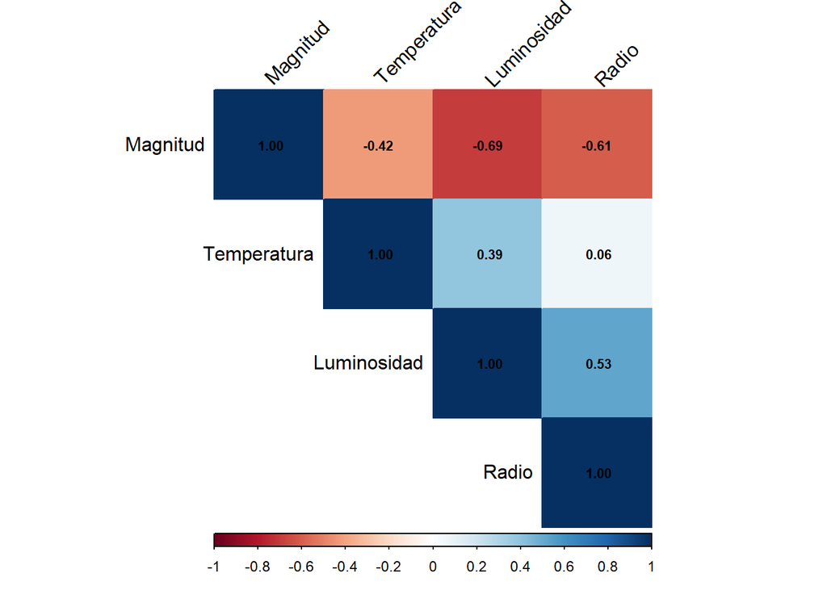

```r
library(corrplot)
corrplot(cor_matrix, method = "color", type = "upper", order = "hclust",
         addCoef.col = "black",
         tl.col = "black", tl.srt = 45,
         cl.pos = "b", cl.cex = 0.75,
         number.cex = 0.7)
```

De la matriu podem extreure:

- Temperatura i Lluminositat (0.39): hi ha una correlació positiva moderada entre la temperatura i la lluminositat d’una estrella, el que significa que a major temperatura, tendeix a haver-hi major lluminositat.
- Lluminositat i Radio (0.53): aquesta és una correlació positiva forta, indicant que les estrelles amb major radi també tendeixen a ser més lluminoses.
- Lluminositat i Magnitud (-0.69): aquesta correlació negativa forta suggereix que a major lluminositat, menor és la magnitud absoluta.
- Radio i Magnitud (-0.61): hi ha una correlació negativa forta, indicant que les estrelles de major radi tendeixen a tenir una magnitud menor.